# Statistical Analysis

Haaland

3/25/2020

## Introduction

The previous visual analysis, I came to the conclusion that the current data, can easily be translated to a form that is suitable for general analysis. In particular, EDVisits is an actual count, not a bin. So if we can recover the “pre-binned” data for EDVisits just by expanding the data based on the count value. Of course, the remaining two variable remain as binned variables, so we need to be sure we treat them as factors in the analysis. Just as a reminder, the data, as extracted and reformatted is shown below.

```r
head(tri_df)
```

```
##   EDVisits RoadwayExposure MaxPMExposure Frequency
## 1        0               1             1       231
## 2        0               2             1       134
## 3        0               3             1       323
## 4        0               4             1       336
## 5        0               5             1       528
## 6        0               6             1      3241
```

## Expanding the data

So the plan, is to replicate each row of the `tri_df` data frame by the value of the variable Frequency. Once we do that, we will also recode the two exposure variables so that they are clearly factors and not numeric. First we create the expanded data frame, then we will check for correctness.

```r
expand_df <- tri_df %>%
  arrange(EDVisits, RoadwayExposure, MaxPMExposure)
expand_df <- tibble(EDVisits = rep(expand_df$EDVisits, expand_df$Frequency),
              RoadwayExposure = rep(expand_df$RoadwayExposure, expand_df$Frequency),
              MaxPMExposure = rep(expand_df$MaxPMExposure, expand_df$Frequency),
              Frequency = rep(expand_df$Frequency, expand_df$Frequency))
```

The following code compares the computed frequencies in the new data frame to those from the original data frame. One complication is that the expansion eliminates all rows in the original data frame that had zero frequency. So we have to adjust for that in code. The test at the end of this block compares the original nonzero Frequencies to those computed from the new data.

```r
check1_df  <- expand_df %>%
  group_by(EDVisits, RoadwayExposure, MaxPMExposure) %>%
  arrange(EDVisits, RoadwayExposure, MaxPMExposure) %>%
  summarize(newFreq = n())
check2_df <- tri_df %>%
  filter(Frequency != 0) %>%
  arrange(EDVisits, RoadwayExposure, MaxPMExposure)
all(check2_df$Frequency==check1_df$newFreq)
```

```
## [1] TRUE
```

Before going further, we are going to modify the two exposures to make sure they will be treated as factors in all subsequent analysis. We will also drop the Frequency variable as that is no longer relevant.

```r
expand_df <- expand_df %>%
  mutate(RoadwayExposure = paste0("RExp=", RoadwayExposure),
         MaxPMExposure = paste0("PMExp=", MaxPMExposure)) %>%
  dplyr::select(-Frequency) %>%
  mutate(RoadwayExposure = as.factor(RoadwayExposure),
         MaxPMExposure = as.factor(MaxPMExposure))
head(expand_df)
```

```
## # A tibble: 6 x 3
##   EDVisits RoadwayExposure MaxPMExposure
##      <dbl> <fct>           <fct>
## 1        0 RExp=1          PMExp=1
## 2        0 RExp=1          PMExp=1
## 3        0 RExp=1          PMExp=1
## 4        0 RExp=1          PMExp=1
## 5        0 RExp=1          PMExp=1
## 6        0 RExp=1          PMExp=1
```

## Graphical analysis

Next we make a few graphs similar to those in the previous file so that we can verify our intuition about the correctness of the data.

### Comparing EdVisits distributions within a particular type of exposure

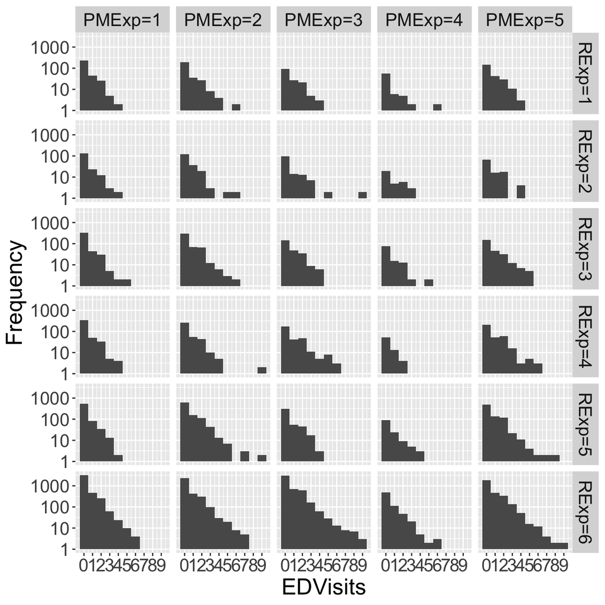

```r
expand_df %>%
  ggplot(aes(x = EDVisits)) +
    geom_histogram(binwidth = 1) +
    facet_grid(RoadwayExposure~MaxPMExposure) +
    labs(y = "Frequency") +
    scale_x_continuous(breaks = 0:9) +
    scale_y_log10() +
    theme(text = element_text(size = 20))
```

## Fitting the GLM model

The data now are organized appropriately and match the assumptions of a generalized linear model with a Poisson family error distribution. Note that the first model we fit includes the interaction between the two exposure types. One of the first tasks of assessing the model is to determine whether or not there is over dispersion. We do that below.

```r
glm_fit1 <- glm(EDVisits  ~ RoadwayExposure*MaxPMExposure,
                data = expand_df,
               family = poisson)
summary(glm_fit1)
```

```
##
## Call:
## glm(formula = EDVisits ~ RoadwayExposure * MaxPMExposure, family = poisson,
##     data = expand_df)
##
## Deviance Residuals:
##     Min       1Q   Median       3Q      Max
## -1.3003  -1.1510  -0.8790   0.3854   6.4677
##
## Coefficients:
##                                            Estimate Std. Error z value Pr(>|z|)
## (Intercept)                                -0.95098    0.09167 -10.374  < 2e-16
## RoadwayExposureRExp=2                      -0.04920    0.15501  -0.317  0.75096
## RoadwayExposureRExp=3                      -0.08802    0.12389  -0.711  0.47738
## RoadwayExposureRExp=4                      -0.11771    0.12331  -0.955  0.33978
## RoadwayExposureRExp=5                      -0.20346    0.11484  -1.772  0.07644
## RoadwayExposureRExp=6                      -0.13834    0.09557  -1.448  0.14775
## MaxPMExposurePMExp=2                        0.33872    0.12313   2.751  0.00594
## MaxPMExposurePMExp=3                        0.56215    0.13529   4.155 3.25e-05
## MaxPMExposurePMExp=4                        0.29810    0.18633   1.600  0.10963
## MaxPMExposurePMExp=5                        0.57941    0.12105   4.787 1.70e-06
## RoadwayExposureRExp=2:MaxPMExposurePMExp=2  0.21178    0.19814   1.069  0.28513
## RoadwayExposureRExp=3:MaxPMExposurePMExp=2  0.31082    0.15899   1.955  0.05059
## RoadwayExposureRExp=4:MaxPMExposurePMExp=2  0.15637    0.16327   0.958  0.33819
## RoadwayExposureRExp=5:MaxPMExposurePMExp=2  0.43656    0.14653   2.979  0.00289
## RoadwayExposureRExp=6:MaxPMExposurePMExp=2  0.08494    0.12845   0.661  0.50842
## RoadwayExposureRExp=2:MaxPMExposurePMExp=3  0.06535    0.21138   0.309  0.75721
## RoadwayExposureRExp=3:MaxPMExposurePMExp=3  0.13795    0.17587   0.784  0.43283
## RoadwayExposureRExp=4:MaxPMExposurePMExp=3  0.33855    0.17080   1.982  0.04746
## RoadwayExposureRExp=5:MaxPMExposurePMExp=3 -0.07776    0.16630  -0.468  0.64007
## RoadwayExposureRExp=6:MaxPMExposurePMExp=3  0.11535    0.13916   0.829  0.40713
## RoadwayExposureRExp=2:MaxPMExposurePMExp=4  0.46366    0.29800   1.556  0.11973
## RoadwayExposureRExp=3:MaxPMExposurePMExp=4  0.16042    0.24095   0.666  0.50554
## RoadwayExposureRExp=4:MaxPMExposurePMExp=4 -0.02336    0.26800  -0.087  0.93053
## RoadwayExposureRExp=5:MaxPMExposurePMExp=4  0.20010    0.23237   0.861  0.38918
## RoadwayExposureRExp=6:MaxPMExposurePMExp=4  0.05896    0.19626   0.300  0.76384
## RoadwayExposureRExp=2:MaxPMExposurePMExp=5  0.11403    0.20760   0.549  0.58282
## RoadwayExposureRExp=3:MaxPMExposurePMExp=5  0.23839    0.16264   1.466  0.14272
## RoadwayExposureRExp=4:MaxPMExposurePMExp=5  0.28098    0.15800   1.778  0.07535
## RoadwayExposureRExp=5:MaxPMExposurePMExp=5  0.21244    0.14573   1.458  0.14491
```

[output cut: 27 more lines]

```
## RoadwayExposureRExp=2:MaxPMExposurePMExp=5
## RoadwayExposureRExp=3:MaxPMExposurePMExp=5
## RoadwayExposureRExp=4:MaxPMExposurePMExp=5 .
## RoadwayExposureRExp=5:MaxPMExposurePMExp=5
## RoadwayExposureRExp=6:MaxPMExposurePMExp=5
## ---
## Signif. codes:  0 '***' 0.001 '**' 0.01 '*' 0.05 '.' 0.1 ' ' 1
##
## (Dispersion parameter for poisson family taken to be 1)
##
##     Null deviance: 34636  on 23035  degrees of freedom
## Residual deviance: 33649  on 23006  degrees of freedom
## AIC: 50553
##
## Number of Fisher Scoring iterations: 6
```

```r
glm_fit2 <- glm(EDVisits  ~ RoadwayExposure*MaxPMExposure,
                data = expand_df,
               family = quasipoisson)
summary(glm_fit2)
```

```
##
## Call:
## glm(formula = EDVisits ~ RoadwayExposure * MaxPMExposure, family = quasipoisson,
##     data = expand_df)
##
## Deviance Residuals:
##     Min       1Q   Median       3Q      Max
## -1.3003  -1.1510  -0.8790   0.3854   6.4677
##
## Coefficients:
##                                            Estimate Std. Error t value Pr(>|t|)
## (Intercept)                                -0.95098    0.12774  -7.445 1.01e-13
## RoadwayExposureRExp=2                      -0.04920    0.21600  -0.228 0.819837
## RoadwayExposureRExp=3                      -0.08802    0.17263  -0.510 0.610129
## RoadwayExposureRExp=4                      -0.11771    0.17183  -0.685 0.493315
## RoadwayExposureRExp=5                      -0.20346    0.16002  -1.271 0.203576
## RoadwayExposureRExp=6                      -0.13834    0.13317  -1.039 0.298912
## MaxPMExposurePMExp=2                        0.33872    0.17157   1.974 0.048371
## MaxPMExposurePMExp=3                        0.56215    0.18853   2.982 0.002868
## MaxPMExposurePMExp=4                        0.29810    0.25964   1.148 0.250928
## MaxPMExposurePMExp=5                        0.57941    0.16868   3.435 0.000594
## RoadwayExposureRExp=2:MaxPMExposurePMExp=2  0.21178    0.27610   0.767 0.443057
## RoadwayExposureRExp=3:MaxPMExposurePMExp=2  0.31082    0.22155   1.403 0.160655
## RoadwayExposureRExp=4:MaxPMExposurePMExp=2  0.15637    0.22751   0.687 0.491893
## RoadwayExposureRExp=5:MaxPMExposurePMExp=2  0.43656    0.20419   2.138 0.032524
## RoadwayExposureRExp=6:MaxPMExposurePMExp=2  0.08494    0.17899   0.475 0.635097
## RoadwayExposureRExp=2:MaxPMExposurePMExp=3  0.06535    0.29455   0.222 0.824432
## RoadwayExposureRExp=3:MaxPMExposurePMExp=3  0.13795    0.24507   0.563 0.573520
## RoadwayExposureRExp=4:MaxPMExposurePMExp=3  0.33855    0.23800   1.422 0.154904
## RoadwayExposureRExp=5:MaxPMExposurePMExp=3 -0.07776    0.23173  -0.336 0.737200
## RoadwayExposureRExp=6:MaxPMExposurePMExp=3  0.11535    0.19391   0.595 0.551923
## RoadwayExposureRExp=2:MaxPMExposurePMExp=4  0.46366    0.41525   1.117 0.264192
## RoadwayExposureRExp=3:MaxPMExposurePMExp=4  0.16042    0.33575   0.478 0.632797
## RoadwayExposureRExp=4:MaxPMExposurePMExp=4 -0.02336    0.37345  -0.063 0.950115
## RoadwayExposureRExp=5:MaxPMExposurePMExp=4  0.20010    0.32380   0.618 0.536608
## RoadwayExposureRExp=6:MaxPMExposurePMExp=4  0.05896    0.27348   0.216 0.829295
## RoadwayExposureRExp=2:MaxPMExposurePMExp=5  0.11403    0.28929   0.394 0.693455
## RoadwayExposureRExp=3:MaxPMExposurePMExp=5  0.23839    0.22663   1.052 0.292874
## RoadwayExposureRExp=4:MaxPMExposurePMExp=5  0.28098    0.22017   1.276 0.201898
## RoadwayExposureRExp=5:MaxPMExposurePMExp=5  0.21244    0.20307   1.046 0.295507
```

[output cut: 27 more lines]

```
## RoadwayExposureRExp=2:MaxPMExposurePMExp=5
## RoadwayExposureRExp=3:MaxPMExposurePMExp=5
## RoadwayExposureRExp=4:MaxPMExposurePMExp=5
## RoadwayExposureRExp=5:MaxPMExposurePMExp=5
## RoadwayExposureRExp=6:MaxPMExposurePMExp=5
## ---
## Signif. codes:  0 '***' 0.001 '**' 0.01 '*' 0.05 '.' 0.1 ' ' 1
##
## (Dispersion parameter for quasipoisson family taken to be 1.941725)
##
##     Null deviance: 34636  on 23035  degrees of freedom
## Residual deviance: 33649  on 23006  degrees of freedom
## AIC: NA
##
## Number of Fisher Scoring iterations: 6
```

The following shows the p-value from likelihood-ratio test in which the alternative hypothesis is that a quasi-Poisson GLM with over-dispersion is significantly better than a regular Poisson GLM without over-dispersion. Note the p-value is essentially 0 so we conclude that there is a strong indication of over-dispersion, and we go with the quasi-Poisson family.

```r
pchisq(summary(glm_fit2)$dispersion * glm_fit1$df.residual, glm_fit1$df.residual, lower = F)
```

```
## [1] 0
```

We show the standard diagnostic plots below. We don’t see anything particularly unusual in these plots.

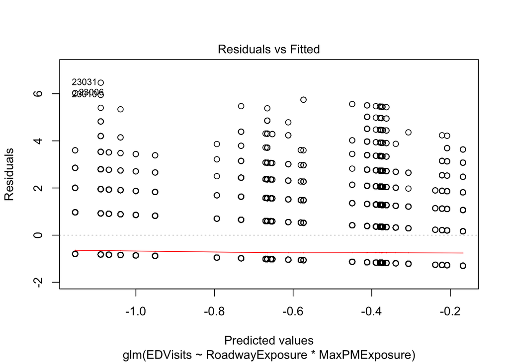

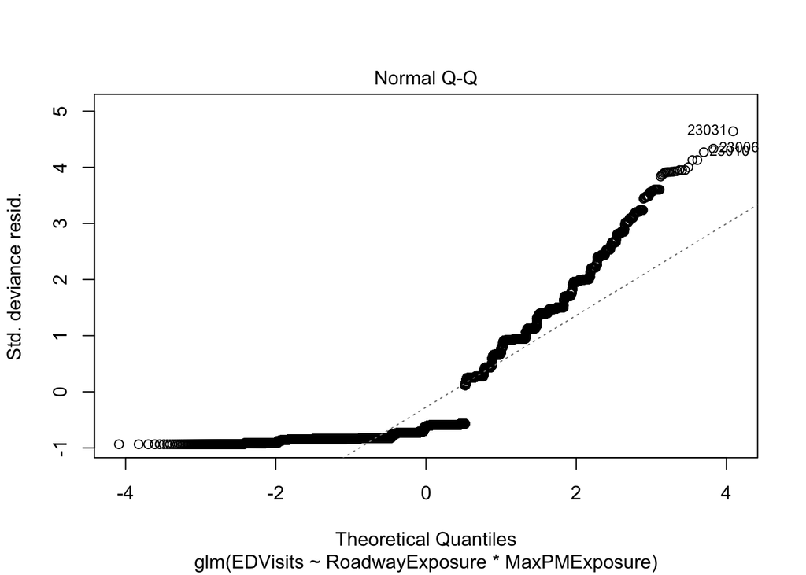

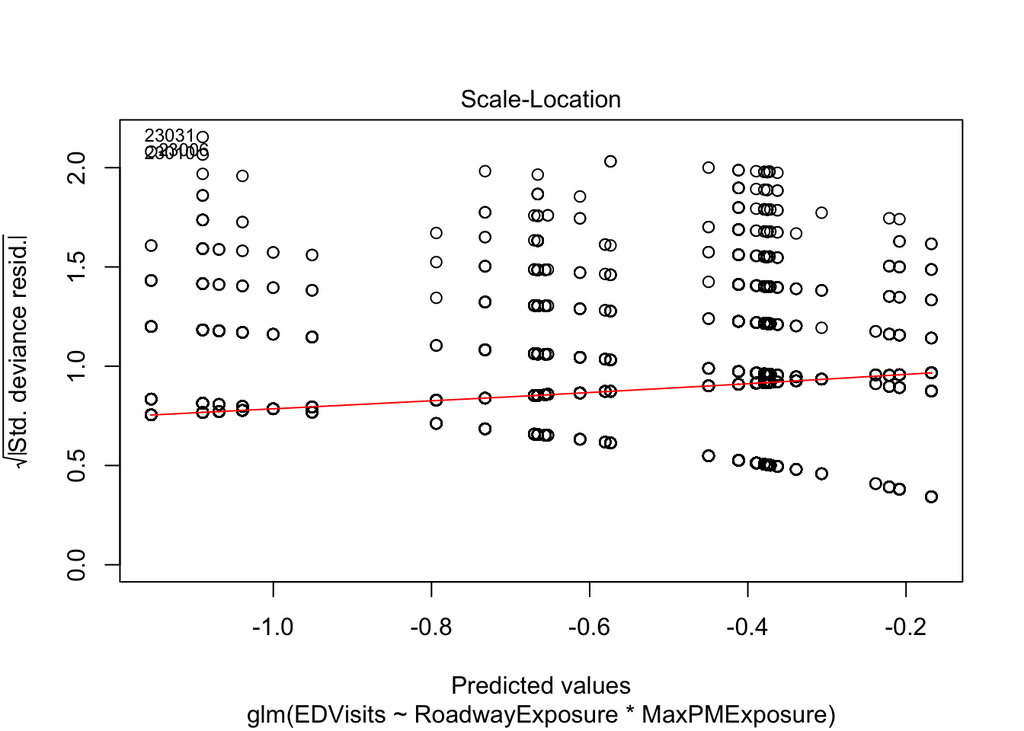

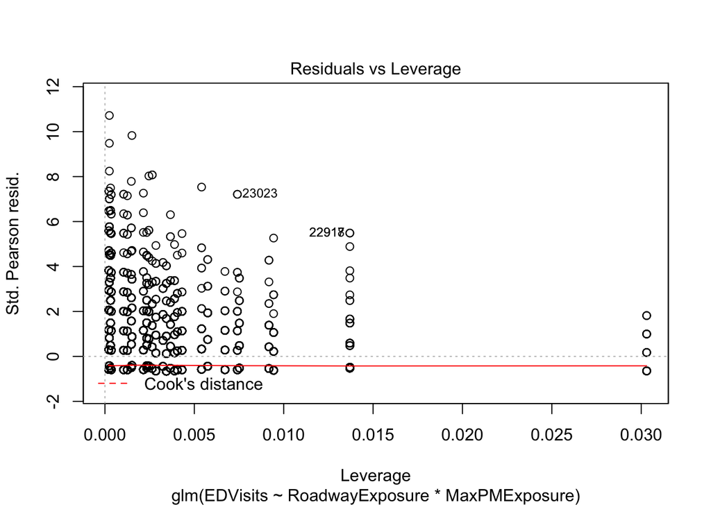

```r
plot(glm_fit2, ask = FALSE)
```

Finally we look at an analysis of variance type summary of the model. We see that both exposure types and their interaction are significant.

```r
summary(aov(glm_fit2))
```

```
##                                  Df Sum Sq Mean Sq F value  Pr(>F)
## RoadwayExposure                   5     13    2.62   2.414 0.03384 *
## MaxPMExposure                     4    464  115.97 106.716 < 2e-16 ***
## RoadwayExposure:MaxPMExposure    20     43    2.17   1.994 0.00519 **
## Residuals                     23006  25002    1.09
## ---
## Signif. codes:  0 '***' 0.001 '**' 0.01 '*' 0.05 '.' 0.1 ' ' 1
```

## Visualizing the model

### Main effect of particle exposure

We use the package `emmeans` to calculate estimated means and confidence intervals for the main effect of `MaxPMExposure`. For this initial plot, we are only considering the “main effect”. A full understanding requires looking at the interaction plot, which we will do shortly.

```r
pmeff_df <- emmeans(glm_fit2, ~ MaxPMExposure) %>%
  as.data.frame %>%
  mutate(pmmean = exp(emmean),
         LCL = exp(asymp.LCL),
         UCL = exp(asymp.UCL))
  pmeff_df
```

```
##   MaxPMExposure     emmean         SE  df  asymp.LCL  asymp.UCL    pmmean
## 1       PMExp=1 -1.0504327 0.04832141 Inf -1.1451410 -0.9557245 0.3497863
## 2       PMExp=2 -0.5116368 0.03689438 Inf -0.5839485 -0.4393251 0.5995135
## 3       PMExp=3 -0.3917103 0.04363208 Inf -0.4772276 -0.3061930 0.6758999
## 4       PMExp=4 -0.6090338 0.08342462 Inf -0.7725430 -0.4455245 0.5438761
## 5       PMExp=5 -0.3076454 0.04005190 Inf -0.3861456 -0.2291451 0.7351760
##         LCL       UCL
## 1 0.3181791 0.3845334
## 2 0.5576920 0.6444712
## 3 0.6205013 0.7362445
## 4 0.4618371 0.6404882
## 5 0.6796715 0.7952132
```

I am not familiar enough with the data to comment on how surprising the plot below is. In particular, I find it odd that the exposure level of 4 shows a decrease as my naive assumption is that emergency visits would increase monotonically with exposure levels.

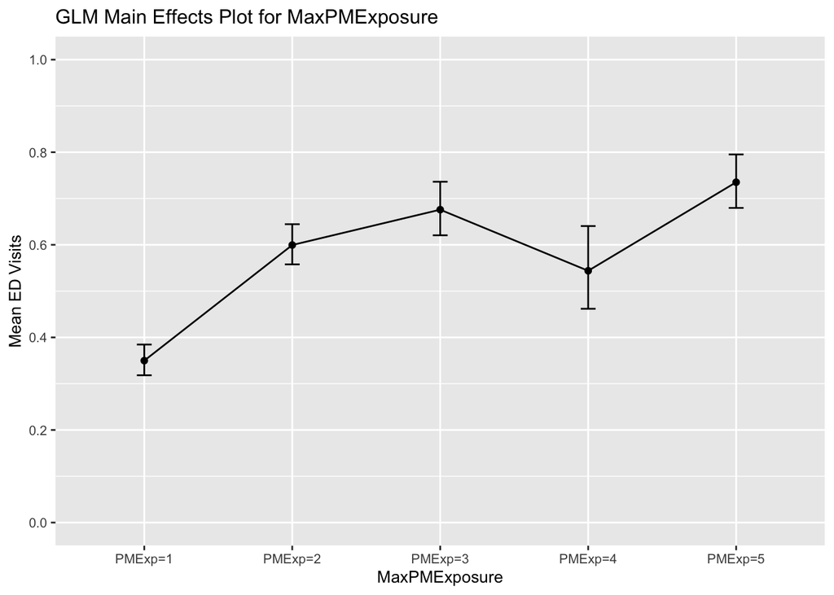

```r
pmeff_df %>%
  ggplot(aes(x = MaxPMExposure, y = pmmean)) +
    geom_point() +
    geom_line(aes(x = 1:5, y = pmmean)) +
    geom_errorbar(aes(ymin = LCL, ymax = UCL), width = .1) +
    labs(y = "Mean ED Visits",
      title = "GLM Main Effects Plot for MaxPMExposure") +
    scale_y_continuous(breaks = seq(0, 1, by = .2),
                       limits = c(0, 1)) +
    theme(text = element_text(size = 10))
```

### Main effect of roadway exposure

Once again, we use the package `emmeans` to calculate estimated means and confidence intervals for the main effect of `RoadwayExposure`. For this initial plot, we are only considering the “main effect”. A full understanding requires looking at the interaction plot, which we will do shortly.

```r
rweff_df <- emmeans(glm_fit2, ~ RoadwayExposure) %>%
  as.data.frame %>%
  mutate(rwmean = exp(emmean),
         LCL = exp(asymp.LCL),
         UCL = exp(asymp.UCL))
  rweff_df
```

```
##   RoadwayExposure     emmean         SE  df  asymp.LCL  asymp.UCL    rwmean
## 1          RExp=1 -0.5952997 0.06690144 Inf -0.7264241 -0.4641753 0.5513973
## 2          RExp=2 -0.4735320 0.08179218 Inf -0.6338417 -0.3132223 0.6227987
## 3          RExp=3 -0.5138086 0.05364263 Inf -0.6189462 -0.4086710 0.5982129
## 4          RExp=4 -0.5625067 0.06192623 Inf -0.6838798 -0.4411335 0.5697790
## 5          RExp=5 -0.6444991 0.04593672 Inf -0.7345335 -0.5544648 0.5249254
## 6          RExp=6 -0.6549047 0.02018518 Inf -0.6944669 -0.6153424 0.5194916
##         LCL       UCL
## 1 0.4836353 0.6286534
## 2 0.5305496 0.7310874
## 3 0.5385116 0.6645329
## 4 0.5046552 0.6433068
## 5 0.4797292 0.5743796
## 6 0.4993406 0.5404558
```

The main effect of roadway exposure shows that there the highest mean is at the exposure level of 2. The impact of RoadwayExposure, by itself, seems to be fairly small. I am not familiar enough with the data to comment on the shape of the curve.

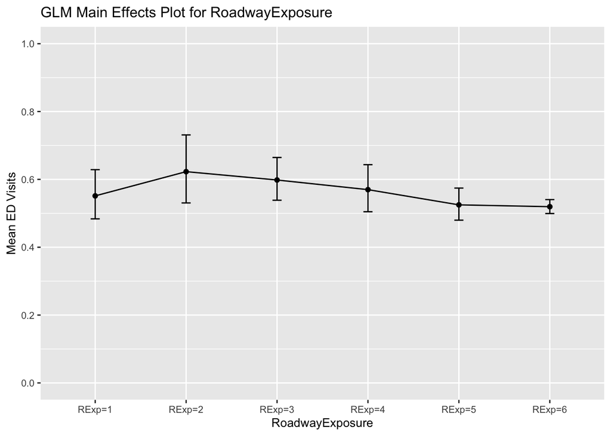

```r
rweff_df %>%
  ggplot(aes(x = RoadwayExposure, y = rwmean)) +
    geom_point() +
    geom_line(aes(x = 1:6, y =rwmean)) +
    geom_errorbar(aes(ymin = LCL, ymax = UCL), width = .1) +
    labs(y = "Mean ED Visits",
      title = "GLM Main Effects Plot for RoadwayExposure") +
    scale_y_continuous(breaks = seq(0, 1, by = .2),
                       limits = c(0, 1)) +
    theme(text = element_text(size = 10))
```

### Interaction effect

Because the two main effects interact significantly, the best interpretation is to make the full interaction plot. In particular, we do the calculations so that we can estimate mean EDVisits at each combination of exposures.

```r
inteff_df <- emmeans(glm_fit2, ~MaxPMExposure*RoadwayExposure) %>%
  as.data.frame %>%
  mutate(intmean = exp(emmean),
         LCL = exp(asymp.LCL),
         UCL = exp(asymp.UCL))
  inteff_df
```

```
##    MaxPMExposure RoadwayExposure     emmean         SE  df  asymp.LCL
## 1        PMExp=1          RExp=1 -0.9509763 0.12773805 Inf -1.2013383
## 2        PMExp=2          RExp=1 -0.6122595 0.11454148 Inf -0.8367567
## 3        PMExp=3          RExp=1 -0.3888258 0.13865424 Inf -0.6605831
## 4        PMExp=4          RExp=1 -0.6528733 0.22604761 Inf -1.0959184
## 5        PMExp=5          RExp=1 -0.3715636 0.11016251 Inf -0.5874781
## 6        PMExp=1          RExp=2 -1.0001722 0.17418217 Inf -1.3415630
## 7        PMExp=2          RExp=2 -0.4496712 0.12827817 Inf -0.7010918
## 8        PMExp=3          RExp=2 -0.3726753 0.14449461 Inf -0.6558795
## 9        PMExp=4          RExp=2 -0.2384110 0.27327957 Inf -0.7740291
## 10       PMExp=5          RExp=2 -0.3067303 0.15777803 Inf -0.6159695
## 11       PMExp=1          RExp=3 -1.0389999 0.11612138 Inf -1.2665936
## 12       PMExp=2          RExp=3 -0.3894648 0.07851245 Inf -0.5433463
## 13       PMExp=3          RExp=3 -0.3389043 0.10503584 Inf -0.5447708
## 14       PMExp=4          RExp=3 -0.5804740 0.17841396 Inf -0.9301590
```

[output cut: 47 more lines]

As we saw above, the average number of emergency visits is generally not a monotone function of particle exposure. The maximum number of visits as a function of particle exposure depends on the roadway exposure. I don’t have the background to suggest a mechanism that might cause this.

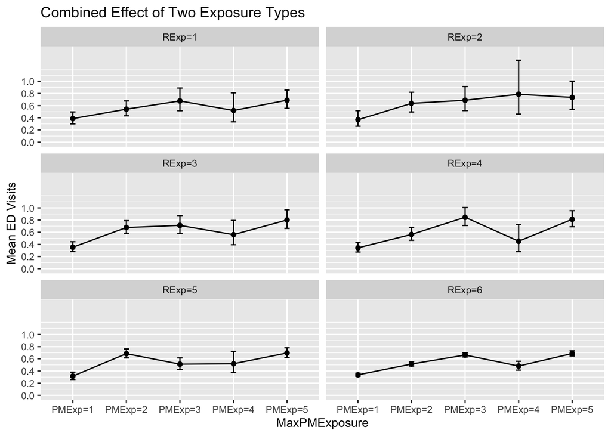

```r
inteff_df %>%
  ggplot(aes(x = MaxPMExposure, y = intmean)) +
    geom_point() +
    geom_line(aes(x = rep(1:5, 6), y = intmean)) +
    geom_errorbar(aes(ymin = LCL, ymax = UCL), width = .1) +
    facet_wrap(~ RoadwayExposure, ncol = 2) +
    labs(y = "Mean ED Visits",
      title = "Combined Effect of Two Exposure Types") +
    scale_y_continuous(breaks = seq(0, 1, by = .2),
                       limits = c(0, 1.5)) +
    theme(text = element_text(size = 10))
```

## Evaluating the statistical model

One of the goals of this project is to identify parameters and statistical measures that can be used to compare the fit of the same type of statistical model to data obtained through the OpenAPI versus behind the firewall. Below we illustrate some code to extract values that could be used to compare two models:

```r
cat("Deviance =", deviance(glm_fit2),"\n\n")
```

```
## Deviance = 33649.08
```

```r
cat("Coefficients =", coefficients(glm_fit2), "\n\n")
```

```
## Coefficients = -0.9509763 -0.04919593 -0.0880236 -0.1177143 -0.2034644 -0.1383404 0.3387168 0.5621505 0.298103 0.5794127 0.2117842 0.3108184 0.1563718 0.4365558 0.08494485 0.06534643 0.137945 0.3385484 -0.07776123 0.1153533 0.4636582 0.1604229 -0.02336428 0.2000951 0.05896381 0.1140292 0.2383872 …
```

```r
em1 <- emmeans(glm_fit2, ~MaxPMExposure*RoadwayExposure) %>%
  as.data.frame
cat("Log Scale Estimated Means = ", em1$emmean, "\n\n")
```

```
## Log Scale Estimated Means =  -0.9509763 -0.6122595 -0.3888258 -0.6528733 -0.3715636 -1.000172 -0.4496712 -0.3726753 -0.238411 -0.3067303 -1.039 -0.3894648 -0.3389043 -0.580474 -0.2211999 -1.068691 -0.573602 -0.1679917 -0.7939519 -0.208297 -1.154441 -0.3791682 -0.6700515 -0.6562426 -0.3625927 -1.0…
```

```r
cat("Log Scale SEs = ", em1$SE, "\n\n")
```

```
## Log Scale SEs =  0.1277381 0.1145415 0.1386542 0.2260476 0.1101625 0.1741822 0.1282782 0.1444946 0.2732796 0.157778 0.1161214 0.07851245 0.1050358 0.178414 0.09708681 0.1149304 0.09547813 0.08884362 0.2425698 0.08254132 0.09638744 0.0544469 0.09416114 0.1677526 0.05909577 0.03766099 0.03439849 0.…
```

For any of the parameter estimates or statistics, two models could be compared by computed the sum of squared differences. The criteria for comparing the models, would need to be developed through experience.